# Logistic Regression

Adam Caffrey

28/12/2020

Logistic regression is analogues to linear regression for binary outcomes. In this example I will estimate whether a customer churned (yes/no) depending on a set of predictors. The dataset used is from [kaggle](https://www.kaggle.com/blastchar/telco-customer-churn), describing Telco Customer Churn.

```r
glimpse(data)
```

```
## Rows: 7,043
## Columns: 21
## $ customerID       <fct> 7590-VHVEG, 5575-GNVDE, 3668-QPYBK, 7795-CFOCW, 9237-…
## $ gender           <fct> Female, Male, Male, Male, Female, Female, Male, Femal…
## $ SeniorCitizen    <int> 0, 0, 0, 0, 0, 0, 0, 0, 0, 0, 0, 0, 0, 0, 0, 0, 0, 0,…
## $ Partner          <fct> Yes, No, No, No, No, No, No, No, Yes, No, Yes, No, Ye…
## $ Dependents       <fct> No, No, No, No, No, No, Yes, No, No, Yes, Yes, No, No…
## $ tenure           <int> 1, 34, 2, 45, 2, 8, 22, 10, 28, 62, 13, 16, 58, 49, 2…
## $ PhoneService     <fct> No, Yes, Yes, No, Yes, Yes, Yes, No, Yes, Yes, Yes, Y…
## $ MultipleLines    <fct> No phone service, No, No, No phone service, No, Yes, …
## $ InternetService  <fct> DSL, DSL, DSL, DSL, Fiber optic, Fiber optic, Fiber o…
## $ OnlineSecurity   <fct> No, Yes, Yes, Yes, No, No, No, Yes, No, Yes, Yes, No …
## $ OnlineBackup     <fct> Yes, No, Yes, No, No, No, Yes, No, No, Yes, No, No in…
## $ DeviceProtection <fct> No, Yes, No, Yes, No, Yes, No, No, Yes, No, No, No in…
## $ TechSupport      <fct> No, No, No, Yes, No, No, No, No, Yes, No, No, No inte…
## $ StreamingTV      <fct> No, No, No, No, No, Yes, Yes, No, Yes, No, No, No int…
## $ StreamingMovies  <fct> No, No, No, No, No, Yes, No, No, Yes, No, No, No inte…
## $ Contract         <fct> Month-to-month, One year, Month-to-month, One year, M…
## $ PaperlessBilling <fct> Yes, No, Yes, No, Yes, Yes, Yes, No, Yes, No, Yes, No…
## $ PaymentMethod    <fct> Electronic check, Mailed check, Mailed check, Bank tr…
## $ MonthlyCharges   <dbl> 29.85, 56.95, 53.85, 42.30, 70.70, 99.65, 89.10, 29.7…
## $ TotalCharges     <dbl> 29.85, 1889.50, 108.15, 1840.75, 151.65, 820.50, 1949…
## $ Churn            <fct> No, No, Yes, No, Yes, Yes, No, No, Yes, No, No, No, N…
```

This data contains 11 NA values.

```r
any(is.na(data))
```

```
## [1] TRUE
```

```r
is.na(data) %>% sum
```

```
## [1] 11
```

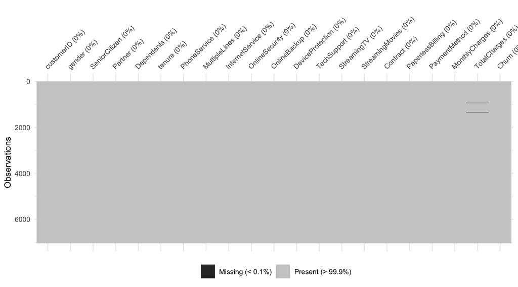

```r
visdat::vis_miss(data)
```

Upon further inspection, all these NA values are found in the TotalCharges column. The total charges are undefined when the tenure (number of months the customer has been with the company) is zero.

```r
data %>%
  filter(is.na(TotalCharges)) %>%
  DT::datatable(class = 'cell-border stripe',
                rownames = FALSE,
                options = list(dom = 'tp',
                               scrollX = TRUE,
                               pageLength = 6,
                               autoWidth = TRUE,
                               columnDefs = list(list(className = "dt-center", targets = 0:20))))
```

| customerID | gender | SeniorCitizen | Partner | Dependents | tenure | PhoneService | MultipleLines | InternetService | OnlineSecurity | OnlineBackup | DeviceProtection | TechSupport | StreamingTV | StreamingMovies | Contract | PaperlessBilling | PaymentMethod | MonthlyCharges | TotalCharges | Churn |
| --- | --- | --- | --- | --- | --- | --- | --- | --- | --- | --- | --- | --- | --- | --- | --- | --- | --- | --- | --- | --- |
| 4472-LVYGI | Female | 0 | Yes | Yes | 0 | No | No phone service | DSL | Yes | No | Yes | Yes | Yes | No | Two year | Yes | Bank transfer (automatic) | 52.55 |  | No |
| 3115-CZMZD | Male | 0 | No | Yes | 0 | Yes | No | No | No internet service | No internet service | No internet service | No internet service | No internet service | No internet service | Two year | No | Mailed check | 20.25 |  | No |
| 5709-LVOEQ | Female | 0 | Yes | Yes | 0 | Yes | No | DSL | Yes | Yes | Yes | No | Yes | Yes | Two year | No | Mailed check | 80.85 |  | No |
| 4367-NUYAO | Male | 0 | Yes | Yes | 0 | Yes | Yes | No | No internet service | No internet service | No internet service | No internet service | No internet service | No internet service | Two year | No | Mailed check | 25.75 |  | No |
| 1371-DWPAZ | Female | 0 | Yes | Yes | 0 | No | No phone service | DSL | Yes | Yes | Yes | Yes | Yes | No | Two year | No | Credit card (automatic) | 56.05 |  | No |
| 7644-OMVMY | Male | 0 | Yes | Yes | 0 | Yes | No | No | No internet service | No internet service | No internet service | No internet service | No internet service | No internet service | Two year | No | Mailed check | 19.85 |  | No |
| 3213-VVOLG | Male | 0 | Yes | Yes | 0 | Yes | Yes | No | No internet service | No internet service | No internet service | No internet service | No internet service | No internet service | Two year | No | Mailed check | 25.35 |  | No |
| 2520-SGTTA | Female | 0 | Yes | Yes | 0 | Yes | No | No | No internet service | No internet service | No internet service | No internet service | No internet service | No internet service | Two year | No | Mailed check | 20 |  | No |
| 2923-ARZLG | Male | 0 | Yes | Yes | 0 | Yes | No | No | No internet service | No internet service | No internet service | No internet service | No internet service | No internet service | One year | Yes | Mailed check | 19.7 |  | No |
| 4075-WKNIU | Female | 0 | Yes | Yes | 0 | Yes | Yes | DSL | No | Yes | Yes | Yes | Yes | No | Two year | No | Mailed check | 73.35 |  | No |

[output cut: 1 more lines]

These are the only zero tenure values in the entire dataset. The missingness is therefore informative and can be replaced with zero values.

```r
data <- mutate(data, TotalCharges=replace(TotalCharges, is.na(TotalCharges), 0))
```

The customer ID column is a unique identifier which is not used in the prediction process, it is therefore removed from the data.

```r
data <- data %>%
  select(-customerID)
```

Here is a complete rundown of the data, the phone service factor has a large imbalance.

```r
Hmisc::describe(data)
```

```
## data
##
##  20  Variables      7043  Observations
## --------------------------------------------------------------------------------
## gender
##        n  missing distinct
##     7043        0        2
##
## Value      Female   Male
## Frequency    3488   3555
## Proportion  0.495  0.505
## --------------------------------------------------------------------------------
## SeniorCitizen
##        n  missing distinct     Info      Sum     Mean      Gmd
##     7043        0        2    0.408     1142   0.1621   0.2717
##
## --------------------------------------------------------------------------------
## Partner
##        n  missing distinct
##     7043        0        2
##
## Value         No   Yes
## Frequency   3641  3402
## Proportion 0.517 0.483
## --------------------------------------------------------------------------------
## Dependents
##        n  missing distinct
##     7043        0        2
##
## Value        No  Yes
## Frequency  4933 2110
## Proportion  0.7  0.3
## --------------------------------------------------------------------------------
## tenure
##        n  missing distinct     Info     Mean      Gmd      .05      .10
##     7043        0       73    0.999    32.37    28.08        1        2
##      .25      .50      .75      .90      .95
##        9       29       55       69       72
##
## lowest :  0  1  2  3  4, highest: 68 69 70 71 72
```

[output cut: 111 more lines]

```
##     7043        0     6531        1     2280     2449    48.60    83.47
##      .25      .50      .75      .90      .95
##   398.55  1394.55  3786.60  5973.69  6921.02
##
## lowest :    0.00   18.80   18.85   18.90   19.00
## highest: 8564.75 8594.40 8670.10 8672.45 8684.80
## --------------------------------------------------------------------------------
## Churn
##        n  missing distinct
##     7043        0        2
##
## Value         No   Yes
## Frequency   5174  1869
## Proportion 0.735 0.265
## --------------------------------------------------------------------------------
```

Next, the numeric data is reviewed using a correlation table. A strong positive correlation between the monthly and total charges is shown - the more monthly charges, the more the total cost. More interestingly though, senior citizen and tenure shows no correlation.

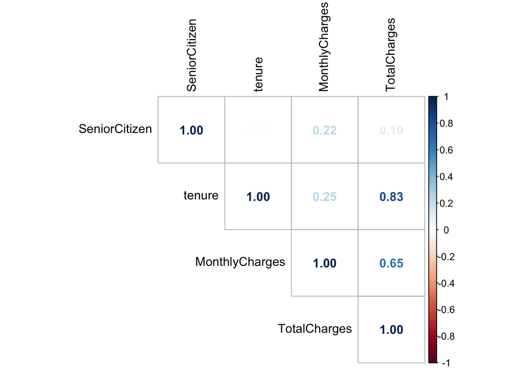

```r
data %>%
  select_if(is.numeric) %>%
  cor %>%
  corrplot::corrplot(type = "upper",
                     tl.col = "black",
                     method = "number")
```

The senior citizen variable is either 1 or 0. This must be recast as a factor before use in the model.

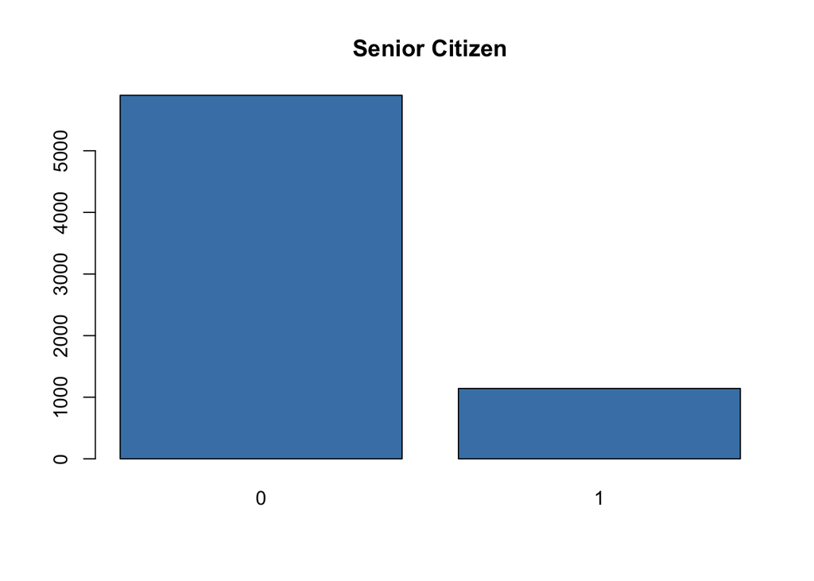

```r
data$SeniorCitizen %>%
  table %>%
  barplot(col = "steelblue", main = "Senior Citizen")
```

The data is split into a training and testing set, stratified sampling is used on the imbalanced phone service variable.

```r
data_split <- initial_split(data, prop = 3/4, strata = PhoneService)
data_train <- training(data_split)
data_test <- testing(data_split)
```

The recipe converts the senior citizen variable to a yes/no factor before dummy encoding all factors. Very little preprocessing is required for this dataset.

```r
lr_recipe <- recipe(Churn ~ ., data_train)  %>%
  step_num2factor(SeniorCitizen,
                  transform = function(x){return(x + 1)},
                  levels = c("No", "Yes"),
                  ordered = F) %>%
  step_dummy(all_nominal(), -all_outcomes())
```

A logistic regression model is selected from the glm library.

```r
lr_model <-
  logistic_reg(mode = "classification") %>%
  set_engine("glm")
```

The workflow object ties the entire process together.

```r
lr_wf <-
 workflow() %>%
 add_model(lr_model) %>%
 add_recipe(lr_recipe)
```

The training data is fit to create the model and coefficients are returned.

```r
(lr_wf_fit <-
  lr_wf %>%
  fit(data_train))
```

```
## ══ Workflow [trained] ══════════════════════════════════════════════════════════
## Preprocessor: Recipe
## Model: logistic_reg()
##
## ── Preprocessor ────────────────────────────────────────────────────────────────
## 2 Recipe Steps
##
## • step_num2factor()
## • step_dummy()
##
## ── Model ───────────────────────────────────────────────────────────────────────
##
## Call:  stats::glm(formula = ..y ~ ., family = stats::binomial, data = data)
##
## Coefficients:
##                           (Intercept)                                 tenure
##                             0.9600053                             -0.0573502
##                        MonthlyCharges                           TotalCharges
##                            -0.0318682                              0.0002789
##                           gender_Male                      SeniorCitizen_Yes
##                            -0.0396671                              0.2946431
##                           Partner_Yes                         Dependents_Yes
##                            -0.0751205                             -0.1338094
##                      PhoneService_Yes         MultipleLines_No.phone.service
##                            -0.0376969                                     NA
##                     MultipleLines_Yes            InternetService_Fiber.optic
##                             0.4225385                              1.5559137
##                    InternetService_No     OnlineSecurity_No.internet.service
##                            -1.5484668                                     NA
##                    OnlineSecurity_Yes       OnlineBackup_No.internet.service
##                            -0.1979712                                     NA
##                      OnlineBackup_Yes   DeviceProtection_No.internet.service
##                             0.0012428                                     NA
##                  DeviceProtection_Yes        TechSupport_No.internet.service
##                             0.0441192                                     NA
##                       TechSupport_Yes        StreamingTV_No.internet.service
##                            -0.1931264                                     NA
##                       StreamingTV_Yes    StreamingMovies_No.internet.service
##                             0.6293459                                     NA
##                   StreamingMovies_Yes                      Contract_One.year
##                             0.5399053                             -0.6815223
##                     Contract_Two.year                   PaperlessBilling_Yes
##                            -1.4071488                              0.3228750
## PaymentMethod_Credit.card..automatic.         PaymentMethod_Electronic.check
##                            -0.0001846                              0.3308429
##            PaymentMethod_Mailed.check
##                             0.0498946
##
## Degrees of Freedom: 5281 Total (i.e. Null);  5258 Residual
## Null Deviance:       6228
## Residual Deviance: 4441  AIC: 4489
```

Using the model, churn is estimated from the test data. Here, the actual and predicted columns are bound for further analysis.

```r
pred <-
  predict(lr_wf_fit, data_test) %>%
  bind_cols(., "truth" = data_test$Churn)

pred %>%
  DT::datatable(class = 'cell-border stripe',
                rownames = FALSE,
                colnames = c("Prediction", "Truth"),
                options = list(dom = 'tp',
                               pageLength = 10,
                               autoWidth = TRUE,
                               columnDefs = list(list(className = "dt-center", targets = 0:1),
                                                 list(width = '200px', targets = "_all"))))
```

| Prediction | Truth |
| --- | --- |
| No | No |
| No | No |
| No | No |
| No | No |
| No | No |
| No | Yes |
| No | No |
| No | Yes |
| No | No |
| No | No |

[output cut: 1751 more lines]

A confusion matrix is an intuitive way to display the results. It allows one to determine the number of true/false positives/negatives.

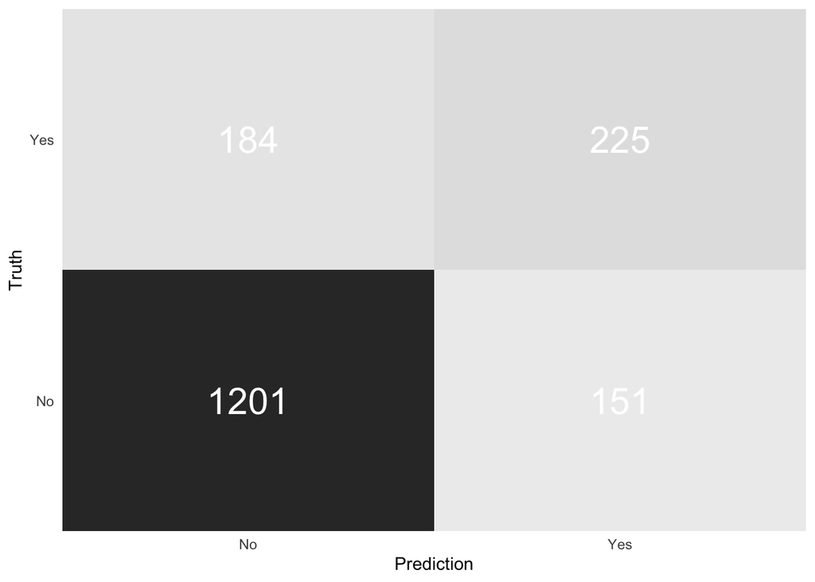

```r
pred %>%
  conf_mat(truth, .pred_class) %>%
  pluck(1) %>%
  as_tibble() %>%
  ggplot(data = ., aes(Prediction, Truth, alpha = n)) +
    geom_tile(show.legend = F) +
    geom_text(aes(label = n), colour = "white", alpha = 1, size = 8) +
    theme_minimal() +
    theme(panel.grid.major = element_blank()) +
    scale_x_discrete(expand = c(0,0)) +
    scale_y_discrete(expand = c(0,0))
```

The metrics function once again returns the model performance. As no custom metrics were requested, the defaults are returned; accuracy and Cohen’s kappa. More detail on these metrics can be found on the model performance page.

```r
pred %>%
  metrics(truth, .pred_class)
```

```
## # A tibble: 2 × 3
##   .metric  .estimator .estimate
##   <chr>    <chr>          <dbl>
## 1 accuracy binary         0.810
## 2 kap      binary         0.451
```

Clearly, this model is not perfect. There are far too many false negatives! More complex models will be introduced in a later script.